# Olist

### Multivariate analysis

#### PCA

Drivers of consumer behavior.

```r
library('ggbiplot')
```

```r
#We had already ran the numericals and dropped redundant columns
#we named the numt
pca <- prcomp(num.col[, 1:16], center = TRUE, scale = TRUE)
summary(pca)
```

```
Importance of components:
                          PC1     PC2     PC3    PC4     PC5    PC6     PC7
Standard deviation     1.8360 1.25311 1.13599 1.0859 1.03483 1.0237 0.97606
Proportion of Variance 0.2107 0.09814 0.08065 0.0737 0.06693 0.0655 0.05954
Cumulative Proportion  0.2107 0.30881 0.38947 0.4632 0.53010 0.5956 0.65514
                           PC8     PC9   PC10    PC11    PC12    PC13    PC14
Standard deviation     0.94771 0.93456 0.9200 0.88383 0.87872 0.69944 0.66419
Proportion of Variance 0.05613 0.05459 0.0529 0.04882 0.04826 0.03058 0.02757
Cumulative Proportion  0.71127 0.76586 0.8188 0.86759 0.91584 0.94642 0.97399
                          PC15    PC16
Standard deviation     0.51815 0.38425
Proportion of Variance 0.01678 0.00923
Cumulative Proportion  0.99077 1.00000
```

```r
str(pca)
```

```
List of 5
 $ sdev    : num [1:16] 1.84 1.25 1.14 1.09 1.03 ...
 $ rotation: num [1:16, 1:16] 0.06596 0.03819 0.36838 0.4103 0.00665 ...
  ..- attr(*, "dimnames")=List of 2
  .. ..$ : chr [1:16] "customer_zip_code_prefix" "order_item_id" "price" "freight_value" ...
  .. ..$ : chr [1:16] "PC1" "PC2" "PC3" "PC4" ...
 $ center  : Named num [1:16] 35053.33 1.2 120.46 20.06 1.09 ...
  ..- attr(*, "names")= chr [1:16] "customer_zip_code_prefix" "order_item_id" "price" "freight_value" ...
 $ scale   : Named num [1:16] 2.98e+04 7.01e-01 1.80e+02 1.58e+01 7.27e-01 ...
  ..- attr(*, "names")= chr [1:16] "customer_zip_code_prefix" "order_item_id" "price" "freight_value" ...
 $ x       : num [1:116565, 1:16] 2.42 4.18 1.95 2.49 1.56 ...
  ..- attr(*, "dimnames")=List of 2
  .. ..$ : chr [1:116565] "1" "2" "3" "4" ...
  .. ..$ : chr [1:16] "PC1" "PC2" "PC3" "PC4" ...
 - attr(*, "class")= chr "prcomp"
```

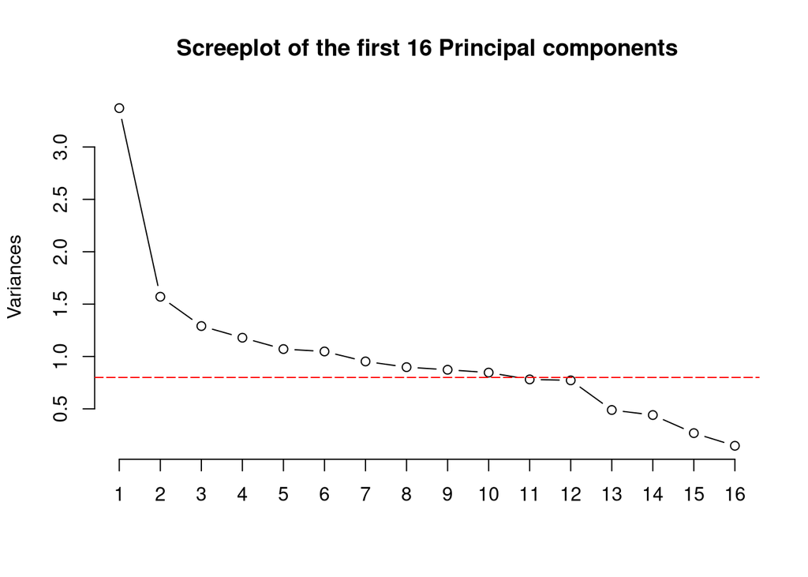

```r
screeplot(pca, type = "l", npcs = 16, main = "Screeplot of the first 16 Principal components")
abline(h = 0.8, col="red", lty=5)
```

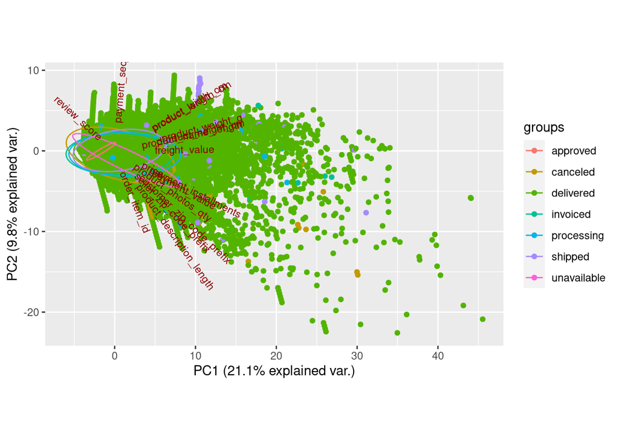

```r
cl_list <- factor(olist$order_status)
ggbiplot(pca, obs.scale = 2, var.scale = 2, groups = cl_list,ellipse = TRUE, circle = TRUE)
```

##**Basket analysis**

```r
library('readxl')
library('lubridate')
library('arules')
library('arulesViz')
```

```r
#Selecting columns from olist that we need to perform MBA
olist.trans <- olist[c("product_category_name_english", "order_id","review_score", "customer_city", "order_purchase_timestamp","price","order_status", "payment_type", "customer_unique_id", "customer_id", "product_id")]
str(olist.trans)
```

```
'data.frame':   116565 obs. of  11 variables:
 $ product_category_name_english: chr  "office_furniture" "housewares" "office_furniture" "office_furniture" ...
 $ order_id                     : chr  "00e7ee1b050b8499577073aeb2a297a1" "29150127e6685892b6eab3eec79f59c7" "b2059ed67ce144a36e2aa97d2c9e9ad2" "951670f92359f4fe4a63112aa7306eba" ...
 $ review_score                 : int  4 5 5 5 5 5 5 5 5 5 ...
 $ customer_city                : chr  "franca" "sao bernardo do campo" "sao paulo" "mogi das cruzes" ...
 $ order_purchase_timestamp     : Date, format: "2017-05-16" "2018-01-12" ...
 $ price                        : num  125 289 140 150 230 ...
 $ order_status                 : chr  "delivered" "delivered" "delivered" "delivered" ...
 $ payment_type                 : chr  "credit_card" "credit_card" "credit_card" "credit_card" ...
 $ customer_unique_id           : chr  "861eff4711a542e4b93843c6dd7febb0" "290c77bc529b7ac935b93aa66c333dc3" "060e732b5b29e8181a18229c7b0b2b5e" "259dac757896d24d7702b9acbbff3f3c" ...
 $ customer_id                  : chr  "06b8999e2fba1a1fbc88172c00ba8bc7" "18955e83d337fd6b2def6b18a428ac77" "4e7b3e00288586ebd08712fdd0374a03" "b2b6027bc5c5109e529d4dc6358b12c3" ...
 $ product_id                   : chr  "a9516a079e37a9c9c36b9b78b10169e8" "4aa6014eceb682077f9dc4bffebc05b0" "bd07b66896d6f1494f5b86251848ced7" "a5647c44af977b148e0a3a4751a09e2e" ...
```

```r
#olist.trans % mutate(Description = as.factor(Description))
library(dplyr)

olist.trans$order_purchase_timestamp <- as.POSIXct(as.character(olist.trans$order_purchase_timestamp), format = "%Y-%m-%d %H:%M:%S")

olist.trans$order_purchase_date <- as.Date(olist.trans$order_purchase_timestamp)

olist.trans$Time <- format(olist.trans$order_purchase_timestamp, "%H:%M:%S")

#olist.trans <- olist.trans[-c(5)]
str(olist.trans)
```

```
'data.frame':   116565 obs. of  13 variables:
 $ product_category_name_english: chr  "office_furniture" "housewares" "office_furniture" "office_furniture" ...
 $ order_id                     : chr  "00e7ee1b050b8499577073aeb2a297a1" "29150127e6685892b6eab3eec79f59c7" "b2059ed67ce144a36e2aa97d2c9e9ad2" "951670f92359f4fe4a63112aa7306eba" ...
 $ review_score                 : int  4 5 5 5 5 5 5 5 5 5 ...
 $ customer_city                : chr  "franca" "sao bernardo do campo" "sao paulo" "mogi das cruzes" ...
 $ order_purchase_timestamp     : POSIXct, format: NA NA ...
 $ price                        : num  125 289 140 150 230 ...
 $ order_status                 : chr  "delivered" "delivered" "delivered" "delivered" ...
 $ payment_type                 : chr  "credit_card" "credit_card" "credit_card" "credit_card" ...
 $ customer_unique_id           : chr  "861eff4711a542e4b93843c6dd7febb0" "290c77bc529b7ac935b93aa66c333dc3" "060e732b5b29e8181a18229c7b0b2b5e" "259dac757896d24d7702b9acbbff3f3c" ...
 $ customer_id                  : chr  "06b8999e2fba1a1fbc88172c00ba8bc7" "18955e83d337fd6b2def6b18a428ac77" "4e7b3e00288586ebd08712fdd0374a03" "b2b6027bc5c5109e529d4dc6358b12c3" ...
 $ product_id                   : chr  "a9516a079e37a9c9c36b9b78b10169e8" "4aa6014eceb682077f9dc4bffebc05b0" "bd07b66896d6f1494f5b86251848ced7" "a5647c44af977b148e0a3a4751a09e2e" ...
 $ order_purchase_date          : Date, format: NA NA ...
 $ Time                         : chr  NA NA NA NA ...
```

Now, to be able to do apply association analysis on our dataset, we need the product IDs. But in our case, the product IDs are *ANONYMIZED*. This is one of the hurdles we had to overcome and find a way around working with our dataset.

What approaches will we use to successfully implement Market Basket Analysis ? > We’ll create 2 models. One for the product categories and the other for the anonymized product IDs; then draw relevant assumptions from these.

## Creating a model from the encrypted product IDs

```r
olist.trans <- olist.trans[order(olist.trans$order_purchase_date ),]

#ddply(dataframe, variables_to_be_used_to_split_data_frame, function_to_be_applied)

itemList <- ddply(olist.trans,c("order_purchase_date", "customer_id", "product_category_name_english"),
                       function(df1)paste(df1$product_id,
                       collapse = ","))
head(itemList)
```

|  | order_purchase_date | customer_id | product_category_name_english | V1 |
| --- | --- | --- | --- | --- |
| 1 |  | 00012a2ce6f8dcda20d059ce98491703 | toys | 64315bd8c0c47303179dd2e25b579d00 |
| 2 |  | 000161a058600d5901f007fab4c27140 | health_beauty | 84183944dc7cddca87a5d384452c1d3c |
| 3 |  | 0001fd6190edaaf884bcaf3d49edf079 | baby | 9df2b21ec85378d71df4404712e17478 |
| 4 |  | 0002414f95344307404f0ace7a26f1d5 | cool_stuff | af3ec22cce878225aae6d9eb6c7a78eb |
| 5 |  | 000379cdec625522490c315e70c7a9fb | bed_bath_table | 868b3136c5b206f91b8208fbfdf2cb7c |
| 6 |  | 0004164d20a9e969af783496f3408652 | sports_leisure | fa23bf270fb9880690b07d09b9f9ff20 |

```r
#The R function paste() concatenates vectors to character and separated results using collapse=[any optional character string ]. Here ',' is used
```

From the item list we group the product ids and the categories with the customer ids and the date that the purchases were made.

However, we only need the product id for analysis hence we’ll drop the other columns.

```r
#We only need item transactions, so remove customerID and Date columns.

itemList$customer_id <- NULL
itemList$order_purchase_date <- NULL
itemList$product_category_name_english <- NULL
colnames(itemList) <- c("items")
head(itemList)
```

|  | items |
| --- | --- |
| 1 | 64315bd8c0c47303179dd2e25b579d00 |
| 2 | 84183944dc7cddca87a5d384452c1d3c |
| 3 | 9df2b21ec85378d71df4404712e17478 |
| 4 | af3ec22cce878225aae6d9eb6c7a78eb |
| 5 | 868b3136c5b206f91b8208fbfdf2cb7c |
| 6 | fa23bf270fb9880690b07d09b9f9ff20 |

```r
#Write the data frame to a csv file and check whether our transaction format is correct.

write.csv(itemList,"market_basket_transactions.csv", quote = FALSE, row.names = FALSE)
```

Now we have our transaction dataset, and it shows the matrix of items being bought together. Let’s load the csv as transactions and see how many transactions we have and what they are.

```r
transactionData <- read.transactions('market_basket_transactions.csv', format = 'basket', sep=',')
transactionData
```

```
transactions in sparse format with
 97988 transactions (rows) and
 32323 items (columns)
```

```r
summary(transactionData)
```

```
transactions as itemMatrix in sparse format with
 97988 rows (elements/itemsets/transactions) and
 32323 columns (items) and a density of 3.186786e-05

most frequent items:
99a4788cb24856965c36a24e339b6058 aca2eb7d00ea1a7b8ebd4e68314663af
                             467                              431
422879e10f46682990de24d770e7f83d d1c427060a0f73f6b889a5c7c61f2ac4
                             352                              323
389d119b48cf3043d311335e499d9c6b                          (Other)
                             311                            99050

element (itemset/transaction) length distribution:
sizes
    1     2     3     4     5     6     7     8
95453  2239   220    55     8     9     3     1

   Min. 1st Qu.  Median    Mean 3rd Qu.    Max.
   1.00    1.00    1.00    1.03    1.00    8.00

includes extended item information - examples:
                            labels
1 00066f42aeeb9f3007548bb9d3f33c38
2 00088930e925c41fd95ebfe695fd2655
3 0009406fd7479715e4bef61dd91f2462
```

```r
# Verifying the object's class
# ---
# This should show us transactions as the type of data that we will need
# ---
#
class(transactionData)
```

```
[1] "transactions"
attr(,"package")
[1] "arules"
```

```
transactions
```

```r
inspect(transactionData[10:15])
```

```
    items
[1] {79ad39409fa4bcc36b4b7f734c79c2a2}
[2] {c53feca3e876804031ed4a4b48ac8f1e}
[3] {c5fff00bf5f821911d676badbb286675}
[4] {ffbe3df3856b1fef3fee8f1264105a89}
[5] {368c6c730842d78016ad823897a372db}
[6] {4eba76ab901d06e619d8d7ac69b3579a}
```

The itemFrequencyPlot() allows us to show the absolute or relative values. If absolute it will plot numeric frequencies of each item independently. If relative it will plot how many times these items have appeared as compared to others, as it’s shown in the following plot.

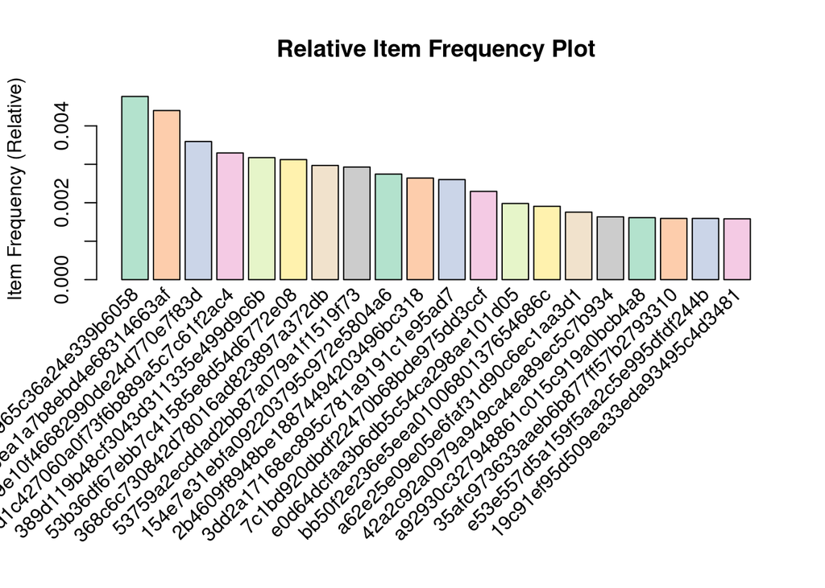

```r
library("RColorBrewer")
arules::itemFrequencyPlot(transactionData,
   topN=20,
   col=brewer.pal(8,'Pastel2'),
   main='Relative Item Frequency Plot',
   type="relative",
   ylab="Item Frequency (Relative)")
```

#Create some rules > 1. We use the *Apriori algorithm* in *Arules library* to mine frequent itemsets and association rules. The algorithm employs level-wise search for frequent itemsets. 2. We pass supp=0.001 and conf=0.8 to return all the rules that have a support of at least 0.1% and confidence of at least 80%. 3. We sort the rules by decreasing confidence

```r
rules <- apriori(transactionData, parameter = list(supp=0.001, conf=0.8))
```

```
Apriori

Parameter specification:
 confidence minval smax arem  aval originalSupport maxtime support minlen
        0.8    0.1    1 none FALSE            TRUE       5   0.001      1
 maxlen target  ext
     10  rules TRUE

Algorithmic control:
 filter tree heap memopt load sort verbose
    0.1 TRUE TRUE  FALSE TRUE    2    TRUE

Absolute minimum support count: 97

set item appearances ...[0 item(s)] done [0.00s].
set transactions ...[32323 item(s), 97988 transaction(s)] done [0.09s].
sorting and recoding items ... [52 item(s)] done [0.01s].
creating transaction tree ... done [0.01s].
checking subsets of size 1 2 done [0.00s].
writing ... [0 rule(s)] done [0.00s].
creating S4 object  ... done [0.02s].
```

```r
rules.1 <- sort(rules, by='confidence', decreasing = TRUE)
summary(rules.1)
```

```
set of 0 rules
```

```r
inspect(rules.1)
```

Building a apriori model with Min Support as 0.002 and confidence as 0.8

```r
rules <- apriori(transactionData, parameter = list(supp=0.002, conf=0.8))
```

```
Apriori

Parameter specification:
 confidence minval smax arem  aval originalSupport maxtime support minlen
        0.8    0.1    1 none FALSE            TRUE       5   0.002      1
 maxlen target  ext
     10  rules TRUE

Algorithmic control:
 filter tree heap memopt load sort verbose
    0.1 TRUE TRUE  FALSE TRUE    2    TRUE

Absolute minimum support count: 195

set item appearances ...[0 item(s)] done [0.00s].
set transactions ...[32323 item(s), 97988 transaction(s)] done [0.11s].
sorting and recoding items ... [12 item(s)] done [0.01s].
creating transaction tree ... done [0.01s].
checking subsets of size 1 2 done [0.00s].
writing ... [0 rule(s)] done [0.00s].
creating S4 object  ... done [0.01s].
```

```r
rules.2 <- sort(rules, by='confidence', decreasing = TRUE)
summary(rules.2)
```

```
set of 0 rules
```

```r
rules <- apriori(transactionData, parameter = list(supp=0.004, conf=0.6))
```

```
Apriori

Parameter specification:
 confidence minval smax arem  aval originalSupport maxtime support minlen
        0.6    0.1    1 none FALSE            TRUE       5   0.004      1
 maxlen target  ext
     10  rules TRUE

Algorithmic control:
 filter tree heap memopt load sort verbose
    0.1 TRUE TRUE  FALSE TRUE    2    TRUE

Absolute minimum support count: 391

set item appearances ...[0 item(s)] done [0.00s].
set transactions ...[32323 item(s), 97988 transaction(s)] done [0.10s].
sorting and recoding items ... [2 item(s)] done [0.01s].
creating transaction tree ... done [0.01s].
checking subsets of size 1 done [0.00s].
writing ... [0 rule(s)] done [0.00s].
creating S4 object  ... done [0.02s].
```

```r
rules.3 <- sort(rules, by='confidence', decreasing = TRUE)
summary(rules.3)
```

```
set of 0 rules
```

##Creating a model using product category names

```r
library(plyr)

olist.trans <- olist.trans[order(olist.trans$order_purchase_date ),]

#ddply(dataframe, variables_to_be_used_to_split_data_frame, function_to_be_applied)

itemList2 <- ddply(olist.trans,c("order_purchase_date", "customer_id", "product_id"),
                       function(df1)paste(df1$product_category_name_english,
                       collapse = ","))
head(itemList2)
```

|  | order_purchase_date | customer_id | product_id | V1 |
| --- | --- | --- | --- | --- |
| 1 |  | 06b8999e2fba1a1fbc88172c00ba8bc7 | a9516a079e37a9c9c36b9b78b10169e8 | office_furniture |
| 2 |  | 18955e83d337fd6b2def6b18a428ac77 | 4aa6014eceb682077f9dc4bffebc05b0 | housewares |
| 3 |  | 4e7b3e00288586ebd08712fdd0374a03 | bd07b66896d6f1494f5b86251848ced7 | office_furniture |
| 4 |  | b2b6027bc5c5109e529d4dc6358b12c3 | a5647c44af977b148e0a3a4751a09e2e | office_furniture |
| 5 |  | 4f2d8ab171c80ec8364f7c12e35b23ad | 9391a573abe00141c56e38d84d7d5b3b | home_confort |
| 6 |  | 879864dab9bc3047522c92c82e1212b8 | 0be701e03657109a8a4d5168122777fb | sports_leisure |

```r
#The R function paste() concatenates vectors to character and separated results using collapse=[any optional character string ]. Here ',' is used
```

```r
#We only need item transactions, so remove customerID and Date columns.

itemList2$customer_id <- NULL
itemList2$order_purchase_date <- NULL
itemList2$product_id <- NULL
colnames(itemList2) <- c("items")
head(itemList2)
```

|  | items |
| --- | --- |
| 1 | office_furniture |
| 2 | housewares |
| 3 | office_furniture |
| 4 | office_furniture |
| 5 | home_confort |
| 6 | sports_leisure |

```r
#Write the data frame to a csv file and check whether our transaction format is correct.
write.csv(itemList2,"market_basket_transactions2.csv", quote = FALSE, row.names = FALSE)
```

Now we have our transaction dataset, and it shows the matrix of items being bought together. Let’s load the csv as transactions and see how many transactions we have and what they are.

```r
transactionData2 <- read.transactions('market_basket_transactions2.csv', format = 'basket', sep=',')
transactionData2
```

```
transactions in sparse format with
 100934 transactions (rows) and
 72 items (columns)
```

```r
summary(transactionData2)
```

```
transactions as itemMatrix in sparse format with
 100934 rows (elements/itemsets/transactions) and
 72 columns (items) and a density of 0.01388889

most frequent items:
       bed_bath_table         health_beauty        sports_leisure
                10156                  9021                  7858
computers_accessories       furniture_decor               (Other)
                 6887                  6781                 60231

element (itemset/transaction) length distribution:
sizes
     1
100934

   Min. 1st Qu.  Median    Mean 3rd Qu.    Max.
      1       1       1       1       1       1

includes extended item information - examples:
                      labels
1 agro_industry_and_commerce
2           air_conditioning
3                        art
```

```r
rules <- apriori(transactionData2, parameter = list(supp=0.001, conf=0.8))
```

```
Apriori

Parameter specification:
 confidence minval smax arem  aval originalSupport maxtime support minlen
        0.8    0.1    1 none FALSE            TRUE       5   0.001      1
 maxlen target  ext
     10  rules TRUE

Algorithmic control:
 filter tree heap memopt load sort verbose
    0.1 TRUE TRUE  FALSE TRUE    2    TRUE

Absolute minimum support count: 100

set item appearances ...[0 item(s)] done [0.00s].
set transactions ...[72 item(s), 100934 transaction(s)] done [0.01s].
sorting and recoding items ... [51 item(s)] done [0.00s].
creating transaction tree ... done [0.03s].
checking subsets of size 1 done [0.00s].
writing ... [0 rule(s)] done [0.00s].
creating S4 object  ... done [0.01s].
```

```r
rules.1a <- sort(rules, by='confidence', decreasing = TRUE)
summary(rules.1a)
```

```
set of 0 rules
```

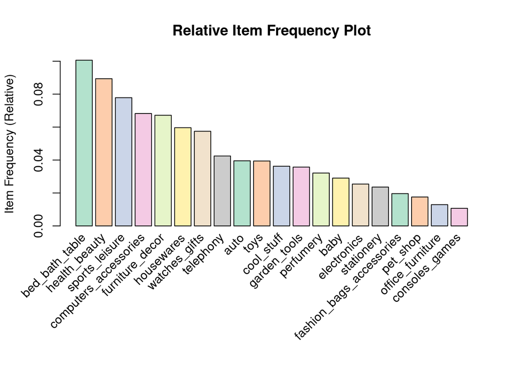

```r
library("RColorBrewer")
arules::itemFrequencyPlot(transactionData2,
   topN=20,
   col=brewer.pal(8,'Pastel2'),
   main='Relative Item Frequency Plot',
   type="relative",
   ylab="Item Frequency (Relative)")
```

##**Polynomial Regression**

We decided to create models to predict the trend of sales over the years,months and days.

```r
x <- olist$order_purchase_timestamp
year <- as.numeric(format(x, format = "%Y"))
month <- as.numeric(format(x, format = "%m"))
day <- as.numeric(format(x, format = "%d"))
dates <- list('year'=year,'month'=month,'day'=day,'revenue'=olist$payment_value)
dates.and.revenues <- as.data.frame(dates)
head(dates.and.revenues)
```

|  | year | month | day | revenue |
| --- | --- | --- | --- | --- |
| 1 | 2017 | 5 | 16 | 146.87 |
| 2 | 2018 | 1 | 12 | 335.48 |
| 3 | 2018 | 5 | 19 | 157.73 |
| 4 | 2018 | 3 | 13 | 173.30 |
| 5 | 2018 | 7 | 29 | 252.25 |
| 6 | 2017 | 9 | 14 | 282.21 |

```r
get_train_validation <- function (dataset){
  # Geting the row numbers for train sample (80% of the dataset)
  train <- sample(seq_len(nrow(dataset)), size = ceiling(0.80*nrow(dataset)), replace = FALSE)
  # training set == part of the dataset in the train sample
  train_set <- dataset[train,]
  # Validation set == part of the dataset not in the train sample
  Validation_set <- dataset[-train,]
  # fix for R not accepting multiple argument returns
  sets <- list("Train" = train_set, "Validation" = Validation_set)
  return (sets)
}
POLY <- function (set,what,deg=2){
  # Geting the train and test sets
  train.data <- set$Train
  test.data  <- set$Validation
  # Build the model
  if(what=='year'){
    model <- lm(revenue ~ poly(year, degree = deg, raw = TRUE), data = train.data)
  }else if(what=='month'){
    model <- lm(revenue ~ poly(month, degree = deg, raw = TRUE), data = train.data)

  }else if(what=='day'){
    model <- lm(revenue ~ poly(day, degree = deg, raw = TRUE), data = train.data)

  }
  # Make predictions
  predictions <- model %>% predict(test.data)
  #Get the rmse scores of the model
  RMSE <- RMSE(predictions, test.data$revenue)
  result <- list('model'=model,'rmse'=RMSE)
  return(result)
}
predict_ <- function (model,object,lists){
  #Creating a dataframe from the list provided
  if(object=='year'){
    nw <- data.frame('year'=lists)
  }else
  if(object=='month'){
    nw <- data.frame('month'=lists)
  }else
  if(object=='day'){
    nw <- data.frame('day'=lists)
  }
  #Predicting the value(s) in the dataframe using the selected model
  xpr <- suppressWarnings(predict(model,nw,type = 'response'))
  return (xpr)#Return the prediction
}
```

```r
rmse_ <- 1000
for (i in 2:10){
  sets <- get_train_validation(dates.and.revenues)
  res <- suppressWarnings(POLY(sets,'year',deg = i))
  if (res$rmse < rmse_){
    best.year_model <- res$model
    degree_ <- i
    rmse_ <- res$rmse
  }
}
print(paste('best degrees for years at',degree_,'degrees'))
```

```
[1] "best degrees for years at 2 degrees"
```

```r
best.year_model <- lm(revenue ~ poly(year, degree = 5, raw = TRUE), data = dates.and.revenues)
```

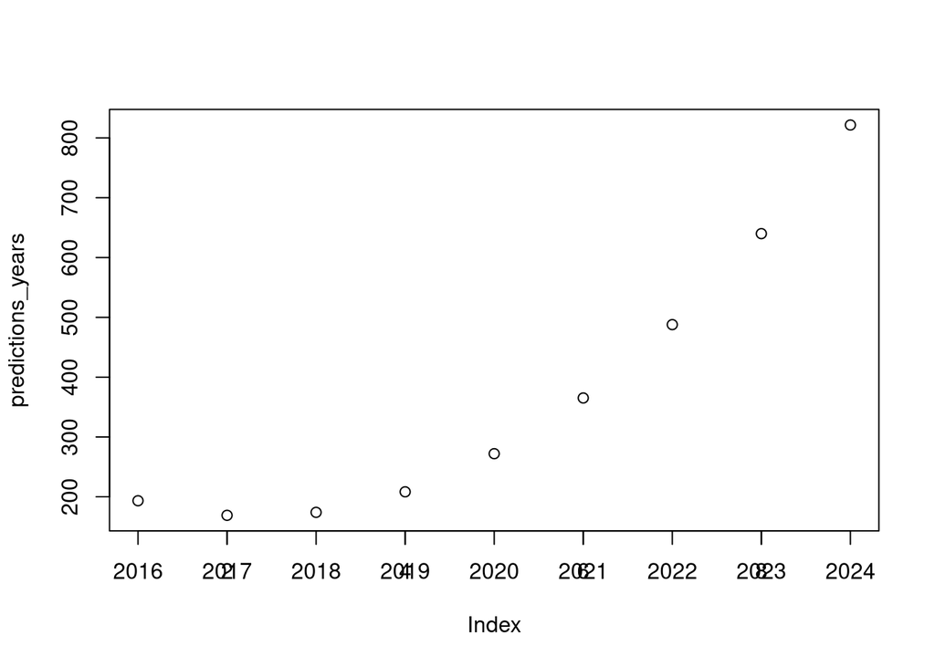

```r
yr <- 2016:2024
predictions_years <- predict_(best.year_model, 'year', yr)
plot(predictions_years)
axis(1,at = 1:9, labels = yr)
```

The model predicts a rising trend in the revenue for the years to come.

```r
rmse_ <- 1000
for (i in 2:10){
  sets <- get_train_validation(dates.and.revenues)
  res <- POLY(sets,'month',deg =i)
  if (res$rmse < rmse_){
    degree_ <- i
    rmse_ <- res$rmse
  }
}
print(paste('best degrees for months at',degree_,'degrees'))
```

```
[1] "best degrees for months at 6 degrees"
```

```r
best.month_model <- lm(revenue ~ poly(month, degree = 7, raw = TRUE), data = dates.and.revenues)
```

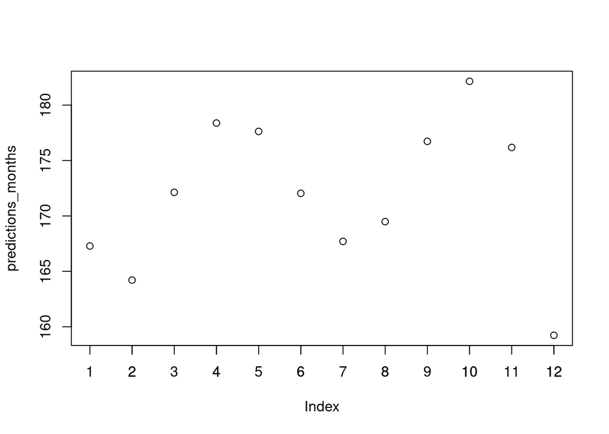

```r
mnth <- 1:12
predictions_months <- predict_(best.month_model, 'month', mnth)
plot(predictions_months)
axis(1,at= 1:12, labels = mnth)
```

The model predicts revenue spikes in april and october. These spikes could be attributed to the holiday seasons.

```r
rmse_ <- 1000
for (i in 2:10){
  sets <- get_train_validation(dates.and.revenues)
  res <- POLY(sets,'day',deg =i)
  if (res$rmse < rmse_){
    degree_ <- i
    rmse_ <- res$rmse
  }
}
print(paste('best degrees for days at',degree_,'degrees'))
```

```
[1] "best degrees for days at 6 degrees"
```

```r
best.day_model <- lm(revenue ~ poly(day, degree = 6, raw = TRUE), data = dates.and.revenues)
```

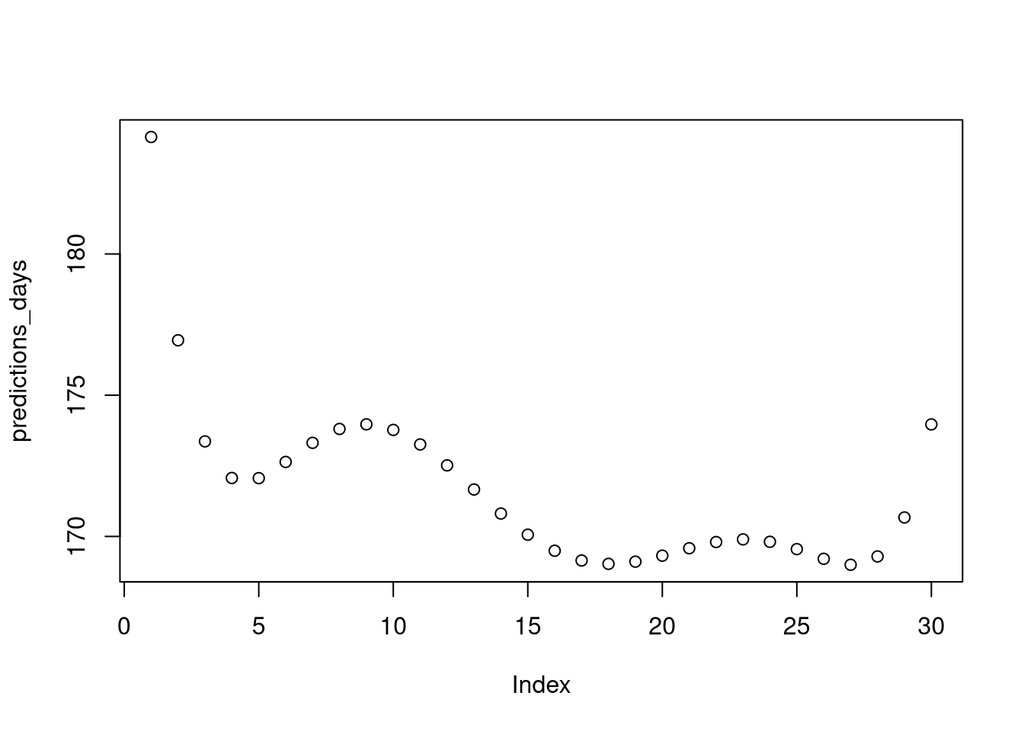

```r
days <- 1:30
predictions_days <- predict_(best.day_model, 'day', days)
plot(predictions_days)
```

The model predicts spikes in revenue at the beginning and end of months, its also is relatively high in the first 11 days and drops to the least around the 20th day of the month. We can assume that most people spend the most once their income salary has been paid and then the reduction in expenditure towards the middle to end month..

# **Recommendations**

From our analysis we realised that :

1.A very large number of Olist customers and sellers are from Sao Paulo and very low percentage from the other towns .Rio recommended to Olist to Recruit more sellers from other towns in turn this will reduce freight fares and in turn.

2.Most customers seemed to be satisfied with products from Olist site and we would recommend the management should also check the poor reviews because the customer complaints create avenues for more revenue.

3.Olist should take advantage of the holidays and give promos on the promos and also reduce on the delivery time.The holidays include: APRIL 20 sao paulo state BRIDGE HOLIDAY in Brazil LABOUR DAY -MAY 1ST-Brazil JUL 09 SÃO PAULO STATE REBELLION DAY-são paulo AUG 09-FATHERS DAY- Brazil SEP 07 -NATIONAL INDEPENDENCE DAY- Brazil